# Common Pool Resources

### Results

### Cumulative harvest

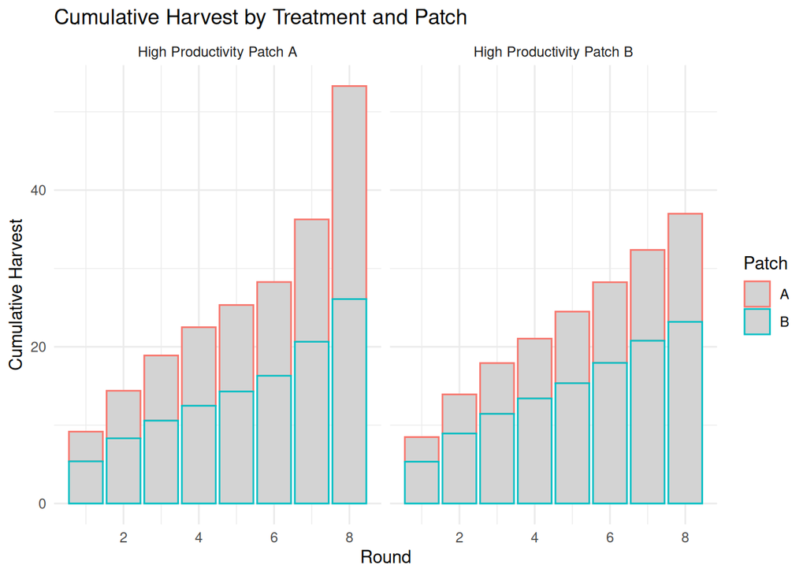

Total harvest is **higher in $A_h$ than in $B_h$** – *Mann-Whitney test p<0.05*

### Cumulative harvest by patch

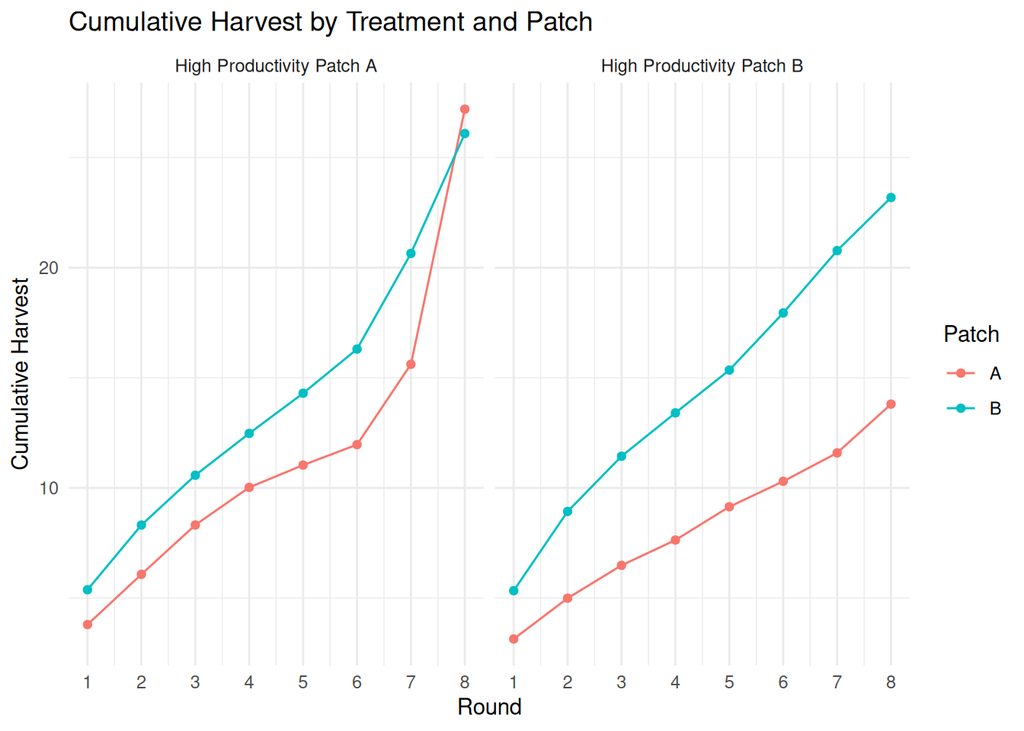

- Players in **Patch B** extract similar quantities in $A_h$ and $B_h$– *MW test p=0.663*
- In $B_h$, the player in **Patch A** extracts much less than in $A_h$ – *MW test p<0.001*

| Num. Obs. 1456 | Harvest |
| --- | --- |
| Patch A x Ah | 2.849*** |
| Patch A x Bh | -1.674*** |
| Patch B x Ah | -0.138 |
| Patch B x Bh | 1.311* |
| Round number | 0.122+ |
| R2 Marg. | 0.013 |
| R2 Cond. | 0.041 |

Compared to Patch A x $A_h$ (ref.):

- **Patch A x $B_h$**: −1.67 units (p < 0.001) → Lower harvest in Patch A when high productivity moves to patch B
- **Patch B x $B_h$**: +1.31 units (p = 0.037) → Negative effect of the high productivity on patch B ($B_h$) is mitigated in Patch B (-1.67 + 1.31 = -0.36)

⇒ Assigning high productivity to Patch B ($B_h$) significantly reduces harvest in Patch A. However, this effect is substantially moderated in Patch B, where the harvest remains nearly stable.

### Findings and implications

- Exclusive rights over high-productivity areas lead to better resource conservation and higher efficiency.
- Shared management leads to early depletion and propagates negative effects to neighboring patches via resource mobility.
- Effective property rights design must account for both ecological productivity and strategic behavior.

## Ongoing related projects

- Introduce and study the impact of risk on the resource within the patches.
- Explore policy interventions to mitigate over-extraction.

# Appendix

## A. Dynamic CPR - Maximization Problems

Two agents $i$ and $j$ exploit a renewable resource $H(t)$ (e.g., groundwater).
Each player’s instantaneous profit is:
$$\pi_i(H, w_i) = a w_i - \frac{b}{2}w_i^2 - \max(0, c_0 - c_1 H)\, w_i$$

The dynamics of the resource stock are:
$$\dot{H}(t) = R - \alpha (w_i + w_j), \qquad H(0) = H_0,$$
where $R > 0$ is the natural recharge, and $\alpha > 0$ the return flow coefficient.
The discount rate is $r > 0$.

### Social Optimum

The planner maximizes the joint discounted net payoffs of both players:
$$\max_{\{w_i(t), w_j(t)\}_{t \ge 0}}
\int_0^{\infty} e^{-rt}
\left[
\sum_{k \in \{i,j\}}
\left( a w_k - \frac{b}{2}w_k^2 - \max(0, c_0 - c_1 H)\, w_k \right)
\right] dt$$
subject to:
$$\dot{H}(t) = R - \alpha (w_i + w_j)$$

#### Hamiltonian

$$\mathcal{H}^S =
\sum_{k \in \{i,j\}}
\left( a w_k - \frac{b}{2}w_k^2 - \max(0, c_0 - c_1 H)\, w_k \right)
+ \lambda^S \big(R - \alpha (w_i + w_j)\big)$$

#### First-order conditions

$$\frac{\partial \mathcal{H}^S}{\partial w_i}
= a - b w_i - \max(0, c_0 - c_1 H) - \alpha \lambda^S = 0,$$
$$\dot{\lambda}^S = r \lambda^S -
\frac{\partial \mathcal{H}^S}{\partial H}
= r \lambda^S -
\sum_{k \in \{i,j\}}
\frac{\partial}{\partial H}
\big[\max(0, c_0 - c_1 H)\, w_k \big].$$

In symmetric equilibrium ($w_i = w_j = w^S$):
$$\dot{H} = R - 2 \alpha w^S, \qquad
a - b w^S - \max(0, c_0 - c_1 H) - \alpha \lambda^S = 0.$$

### Feedback Nash Equilibrium

Each player $i$ maximizes his own discounted payoff, anticipating the other’s feedback rule $w_j(H)$:
$$\max_{\{w_i(t)\}_{t \ge 0}}
\int_0^{\infty} e^{-rt}
\left[a w_i - \frac{b}{2}w_i^2 - \max(0, c_0 - c_1 H)\, w_i \right] dt$$
subject to:
$$\dot{H} = R - \alpha (w_i + w_j(H)).$$

#### Hamiltonian

$$\mathcal{H}_i^F =
a w_i - \frac{b}{2}w_i^2 - \max(0, c_0 - c_1 H)\, w_i
+ \lambda_i^F \big(R - \alpha (w_i + w_j(H))\big)$$

#### First-order conditions

$$\frac{\partial \mathcal{H}_i^F}{\partial w_i}
= a - b w_i - \max(0, c_0 - c_1 H) - \alpha \lambda_i^F = 0,$$
$$\dot{\lambda}_i^F = r \lambda_i^F -
\frac{\partial \mathcal{H}_i^F}{\partial H}
= r \lambda_i^F -
\frac{\partial}{\partial H}\big[\max(0, c_0 - c_1 H)\, w_i \big]
- \lambda_i^F \alpha \frac{dw_j(H)}{dH}.$$

In symmetric equilibrium ($w_i = w_j = w^F(H)$):
$$\dot{H} = R - 2 \alpha w^F(H), \qquad
a - b w^F(H) - \max(0, c_0 - c_1 H) - \alpha \lambda^F = 0.$$

### Myopic Benchmark

At each instant, players maximize only their payoff, taking $H$ as given.

$$\max_{w_i \ge 0} \;
a w_i - \frac{b}{2}w_i^2 - \max(0, c_0 - c_1 H)\, w_i.$$

#### First-order condition

$$a - b w_i - \max(0, c_0 - c_1 H) = 0
\quad \Rightarrow \quad
w_i^M(H) = \frac{a - \max(0, c_0 - c_1 H)}{b}, \quad w_i^M \ge 0.$$

If $H \ge \frac{c_0}{c_1}$ (zero cost), then:
$$w_i^M = \frac{a}{b}.$$

## B. The exponential function in discounting?

The exponential function $e^{-\rho t}$ is used in continuous-time discounting because it has key mathematical and economic properties:

- **Stationary discounting**:  
  Its decay rate is proportional to its current value:  
  $\frac{d}{dt} e^{-\rho t} = -\rho e^{-\rho t}$  
  → No memory, time-consistent discounting.
- **Limit of discrete discounting**:  
  $\lim_{n \to \infty} \left(1 + \frac{r}{n}\right)^{-nt} = e^{-rt}$
- **Simplifies dynamic optimization**:
  $$\int_0^\infty e^{-\rho t} G(t) dt \quad \text{is tractable and interpretable.}$$
- **Avoids abrupt changes**:  
  Smooth and continuous decrease of value over time.

> *Future payoffs are worth less today, at a continuously decreasing rate.*